# Guidelines for parameter uncertainty propagation in matrix population models

## Results: General review results

Headlines of results from review:

- **80.8 % of papers report some uncertainty**
- **for 49.4 % of papers that report some uncertainty the uncertainty is incomplete** for 9 papers it is survival missing and for 10 it is fecundity missing. For 22 papers it is both survival and fecundity missing and only uncertainty in derived elements reported.
- **80.3 % of papers that report uncertainty propagate some of it**
- **79.6 % of parameters with reported uncertainty are propagated**
- **42.5% of lambdas with reported uncertainty have a confidence/credible interval that spans 1**
- **Large variety in metrics of uncertainty reporting: standard errors = 37.7%, confidence Interval = 24%, standard deviation = 21.9%, credible interval = 6%, process variance = 3.7%** Notes that standard deviation isn’t always a true measure of uncertainty. Sometimes it did represent the standard deviation of a sampling distribution but in other cases it was the standard deviation of the data not corrected for sample size. This was sometimes used to represent sampling uncertainty in subsequent bootstrapping or parameteric resampling, but this is not necessarily a correct representation of uncertainty in the vital rate.

## Results: Impact of different propagation scenarios

Overall, there was a minimal impact of matrix size on the impact of uncertainty propagation on conclusions or the bias introduced by partial propagation (see section below for more detail).

### Propagation: by fecundity:survival ratio

Results shown for 3x3 matrix under median uncertainty but across all ratios of survival: fecundity. Goes from survival dominant (1) to fecundity dominant (5).

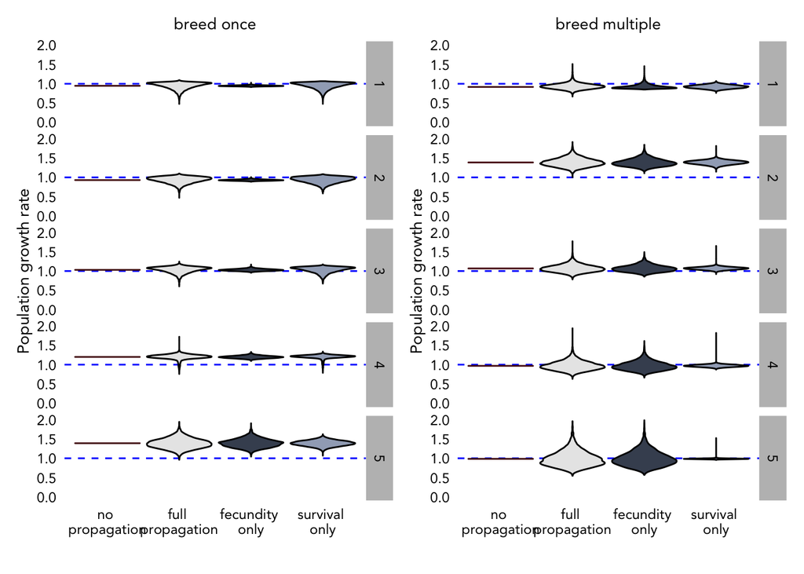

*Figure 1: Violin plots of full distribution of lambda estimates from resampled matrices. Rows show different base matrices sorted by feduncity:survival ratio (1 = survival dominant, 5 = fecundity dominant). All results are for median uncertainty. Dashed line indicates a lambda of 1.*

Results show a shift in the bias caused by partial propagation. Specifically, survival dominant matrices have full uncertainty distributions that are mainly controlled by survival uncertainty and fecundity dominant matrices have full uncertainty distributions that are mainly controlled by fecundity uncertainty. Therefore, omitting survival uncertainty for a survival dominant species would give rise to greater bias in the result than omitting fecundity uncertainty and vice versa for fecundity dominant species.

Fecundity uncertainty is overall more important for species that breed in multiple stages.

### Elasticity changes

Most scenarios are robust to changes in elasticity. I have highlighted one below that sees more variation. This is for species that breed once in a 5x5 matrix under both mid and high uncertainty.

```
## 'matrix_number'. You can override using the `.groups` argument.
```

```
## 'matrix_number', 'prop_scenario', 'uncertainty_level'. You can override using
```

```
## # A tibble: 20 × 5
##    matrix_size breeding_stages matrix_number prop_scenario        percentage
##    <chr>       <chr>                   <int> <fct>                     <dbl>
##  1 size 5      one                         1 "no \npropagation"        100
##  2 size 5      one                         1 "full \npropagation"       99.9
##  3 size 5      one                         1 "fecundity \nonly"        100
##  4 size 5      one                         1 "survival \nonly"          99.9
##  5 size 5      one                         2 "no \npropagation"        100
##  6 size 5      one                         2 "full \npropagation"       70.6
##  7 size 5      one                         2 "fecundity \nonly"         79.4
##  8 size 5      one                         2 "survival \nonly"          72.3
##  9 size 5      one                         3 "no \npropagation"        100
## 10 size 5      one                         3 "full \npropagation"       33.6
## 11 size 5      one                         3 "fecundity \nonly"         44.6
## 12 size 5      one                         3 "survival \nonly"          34.4
## 13 size 5      one                         4 "no \npropagation"         50
## 14 size 5      one                         4 "full \npropagation"       18.1
## 15 size 5      one                         4 "fecundity \nonly"         25.1
## 16 size 5      one                         4 "survival \nonly"          18.6
## 17 size 5      one                         5 "no \npropagation"        100
## 18 size 5      one                         5 "full \npropagation"       18.0
## 19 size 5      one                         5 "fecundity \nonly"         17.5
## 20 size 5      one                         5 "survival \nonly"          17.5
```